# **Introducción a la Modelación de Datos Espaciales usando R**

## 7.2 Modelo Espacial Autorregresio combinado (SAC)

$$\boldsymbol{y}= \rho \boldsymbol{Wy} + \boldsymbol{X} \beta +
\boldsymbol{u}$$

$$\boldsymbol{u} = \lambda \boldsymbol{Wu} + \boldsymbol{\varepsilon}$$

```r
bg.lag.error <- spatialreg::sacsarlm(lograte ~  mean_size + minor + elder
                         + ingresos_bajos + higher,
                         data=bg_data2, bgQ1.gal, method = "eigen", quiet=FALSE)
```

[output not shown]

[output cut: 167 more lines]

[output not shown]

```r
summary(bg.lag.error)
```

```
##
## Call:spatialreg::sacsarlm(formula = lograte ~ mean_size + minor +
##     elder + ingresos_bajos + higher, data = bg_data2, listw = bgQ1.gal,
##     method = "eigen", quiet = FALSE)
##
## Residuals:
##       Min        1Q    Median        3Q       Max
## -1.232417 -0.078367  0.026231  0.130144  0.344188
##
## Type: sac
## Coefficients: (asymptotic standard errors)
##                   Estimate  Std. Error z value  Pr(>|z|)
## (Intercept)     0.18469836  0.28420671  0.6499 0.5157740
## mean_size       0.21019132  0.08704253  2.4148 0.0157433
## minor          -0.02602517  0.00813567 -3.1989 0.0013796
## elder          -0.02510307  0.00669220 -3.7511 0.0001761
## ingresos_bajos -0.00054825  0.00193490 -0.2834 0.7769084
## higher         -0.00348994  0.00269398 -1.2955 0.1951609
##
## Rho: 0.75313
## Asymptotic standard error: 0.095691
##     z-value: 7.8705, p-value: 3.5527e-15
## Lambda: -0.73678
## Asymptotic standard error: 0.22381
##     z-value: -3.292, p-value: 0.00099467
##
## LR test value: 15.998, p-value: 0.00033587
##
## Log likelihood: 1.938789 for sac model
## ML residual variance (sigma squared): 0.043777, (sigma: 0.20923)
## Number of observations: 106
## Number of parameters estimated: 9
## AIC: 14.122, (AIC for lm: 26.12)
```

```r
bg.lag.error.imp <- impacts(bg.lag.error, listw = bgQ1.gal, R = 999)
summary(bg.lag.error.imp, zstats = TRUE, short = TRUE)
```

```
## Impact measures (sac, exact):
##                       Direct     Indirect        Total
## mean_size       0.2555053271  0.595924462  0.851429790
## minor          -0.0316357927 -0.073785322 -0.105421114
## elder          -0.0305149029 -0.071171029 -0.101685932
## ingresos_bajos -0.0006664492 -0.001554384 -0.002220833
## higher         -0.0042423228 -0.009894525 -0.014136848
## ========================================================
## Simulation results ( variance matrix):
## ========================================================
## Simulated standard errors
##                     Direct   Indirect      Total
## mean_size      0.117244436 2.74782116 2.80182821
## minor          0.011643056 0.31804750 0.32401832
## elder          0.009412590 0.26980780 0.27462304
## ingresos_bajos 0.002444485 0.02105394 0.02239151
## higher         0.003431210 0.02710717 0.02882040
##
## Simulated z-values:
##                    Direct    Indirect       Total
## mean_size       2.2360801  0.32604781  0.41333334
## minor          -2.8142791 -0.35878453 -0.45329947
## elder          -3.3507190 -0.39669259 -0.50458148
## ingresos_bajos -0.3069593 -0.06396763 -0.09365727
## higher         -1.2816549 -0.42711370 -0.55431123
##
## Simulated p-values:
##                Direct     Indirect Total
## mean_size      0.02534653 0.74439  0.67936
## minor          0.00488868 0.71976  0.65033
## elder          0.00080602 0.69159  0.61385
## ingresos_bajos 0.75887435 0.94900  0.92538
## higher         0.19996374 0.66930  0.57937
```

```r
# Test de multiplicadores de Lagrange (i.e. GeoDa-style Lagrange multiplier tests)
lm.LMtests(reg_mco, bgQ1.gal, test=c("LMerr", "LMlag", "RLMerr", "RLMlag", "SARMA"))
```

```
##
##  Rao's score (a.k.a Lagrange multiplier) diagnostics for spatial
##  dependence
##
## data:
## model: lm(formula = lograte ~ mean_size + minor + elder +
## ingresos_bajos + higher, data = bg.df)
## test weights: listw
##
## RSerr = 2.4336, df = 1, p-value = 0.1188
##
##
##  Rao's score (a.k.a Lagrange multiplier) diagnostics for spatial
##  dependence
##
## data:
## model: lm(formula = lograte ~ mean_size + minor + elder +
## ingresos_bajos + higher, data = bg.df)
## test weights: listw
##
## RSlag = 8.6525, df = 1, p-value = 0.003266
##
##
##  Rao's score (a.k.a Lagrange multiplier) diagnostics for spatial
##  dependence
##
## data:
## model: lm(formula = lograte ~ mean_size + minor + elder +
## ingresos_bajos + higher, data = bg.df)
## test weights: listw
##
## adjRSerr = 6.0054, df = 1, p-value = 0.01426
##
##
##  Rao's score (a.k.a Lagrange multiplier) diagnostics for spatial
##  dependence
##
## data:
## model: lm(formula = lograte ~ mean_size + minor + elder +
## ingresos_bajos + higher, data = bg.df)
## test weights: listw
##
## adjRSlag = 12.224, df = 1, p-value = 0.0004717
##
##
##  Rao's score (a.k.a Lagrange multiplier) diagnostics for spatial
##  dependence
##
## data:
## model: lm(formula = lograte ~ mean_size + minor + elder +
## ingresos_bajos + higher, data = bg.df)
## test weights: listw
##
## SARMA = 14.658, df = 2, p-value = 0.0006562
```

```r
# Veamos la comparación de la autocorrelación en los residuos
moran.test(reg_mco$residuals, bgQ1.gal, alternative="two.sided")
```

```
##
##  Moran I test under randomisation
##
## data:  reg_mco$residuals
## weights: bgQ1.gal
##
## Moran I statistic standard deviate = 1.8613, p-value = 0.06271
## alternative hypothesis: two.sided
## sample estimates:
## Moran I statistic       Expectation          Variance
##       0.096573547      -0.009523810       0.003249357
```

```r
moran.test(bg.lag.eig$residuals, bgQ1.gal, alternative="two.sided")
```

```
##
##  Moran I test under randomisation
##
## data:  bg.lag.eig$residuals
## weights: bgQ1.gal
##
## Moran I statistic standard deviate = -1.0507, p-value = 0.2934
## alternative hypothesis: two.sided
## sample estimates:
## Moran I statistic       Expectation          Variance
##      -0.068932075      -0.009523810       0.003196956
```

```r
moran.test(bg.err.eig$residuals, bgQ1.gal, alternative="two.sided")
```

```
##
##  Moran I test under randomisation
##
## data:  bg.err.eig$residuals
## weights: bgQ1.gal
##
## Moran I statistic standard deviate = 0.03668, p-value = 0.9707
## alternative hypothesis: two.sided
## sample estimates:
## Moran I statistic       Expectation          Variance
##      -0.007455822      -0.009523810       0.003178640
```

```r
moran.test(bg.slx.eig$residuals, bgQ1.gal, alternative="two.sided")
```

```
##
##  Moran I test under randomisation
##
## data:  bg.slx.eig$residuals
## weights: bgQ1.gal
##
## Moran I statistic standard deviate = 2.0885, p-value = 0.03676
## alternative hypothesis: two.sided
## sample estimates:
## Moran I statistic       Expectation          Variance
##       0.112084957      -0.009523810       0.003390634
```

```r
moran.test(bg.lag.error$residuals, bgQ1.gal, alternative="two.sided")
```

```
##
##  Moran I test under randomisation
##
## data:  bg.lag.error$residuals
## weights: bgQ1.gal
##
## Moran I statistic standard deviate = 0.31003, p-value = 0.7565
## alternative hypothesis: two.sided
## sample estimates:
## Moran I statistic       Expectation          Variance
##       0.008225920      -0.009523810       0.003277731
```

```r
# Veamos la comparación según los criterios de información
AIC(reg_mco)       # 26.12001
```

```
## [1] 26.12001
```

```r
AIC(bg.lag.eig)    # 18.69224
```

```
## [1] 18.69224
```

```r
AIC(bg.err.eig)    # 25.15315
```

```
## [1] 25.15315
```

```r
AIC(bg.slx.eig)    # 17.64841
```

```
## [1] 17.64841
```

```r
AIC(bg.lag.error)    # 14.12242
```

```
## [1] 14.12242
```

```r
BIC(reg_mco)       # 44.76408
```

```
## [1] 44.76408
```

```r
BIC(bg.lag.eig)    # 39.99975
```

```
## [1] 39.99975
```

```r
BIC(bg.err.eig)    # 46.46066
```

```
## [1] 46.46066
```

```r
BIC(bg.slx.eig)    # 49.60968
```

```
## [1] 49.60968
```

```r
BIC(bg.lag.error)    # 38.09337
```

```
## [1] 38.09337
```

**Hay mas**

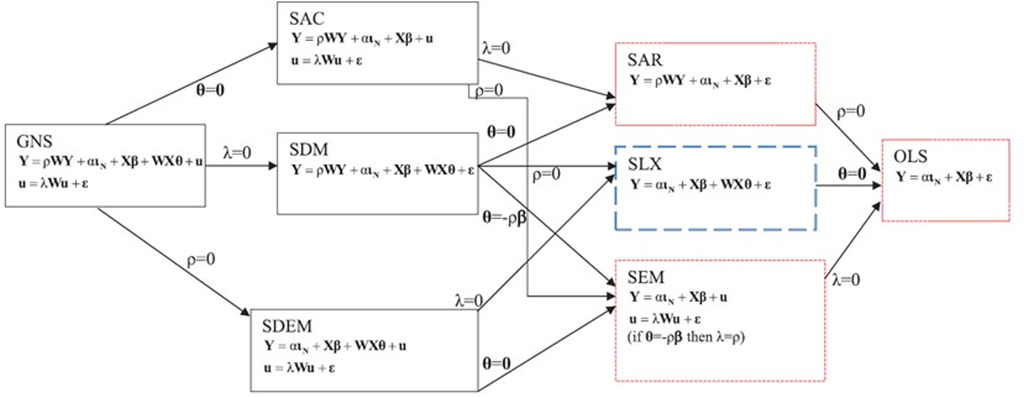

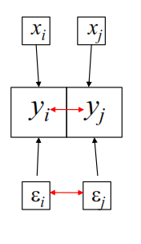

Tipo de archivos necesarios:

Archivo Shape, extensión .shp. Contiene la información espacial más los atributos. Significa que formarán parte otros ficheros como shx, .dbf, y .prj. Desarrollado por ESRI

# 8 Referencias

- Root, E. Class Notes. (2015). Introduction to Spatial Regression Analysis. ICPSR Summer Workshop 2015.
- Dubé, J. , & Legros, D. (2014). Spatial econometrics using microdata.
- LeSage, J. P. , & Pace, R. K. (2009). Introduction to spatial econometrics. Boca Raton: CRC Press.
- Bivand, R. , E.J. Pebesma and V. Gomez-Rubio. (2013). Applied Spatial Data Analysis with R. New York: Springer.